# Intro to Splines

Glenn Palmer

2023-02-02

## Motivation

A common issue when fitting a linear regression model is that one or more of the covariates of interest may not actually have a linear relationship with the outcome. For example, consider the toy example generated below. The graph shows 100 points simulated by drawing x-values uniformly from $[0, 10]$ and then corresponding y-values from
$$y_i = 3 +
\cos(x_i) \sqrt x_i - 0.05x_i^2 + \varepsilon_i, \,\,\,\,\,\,\,
\varepsilon_i \sim N(0, 0.3^2)$$

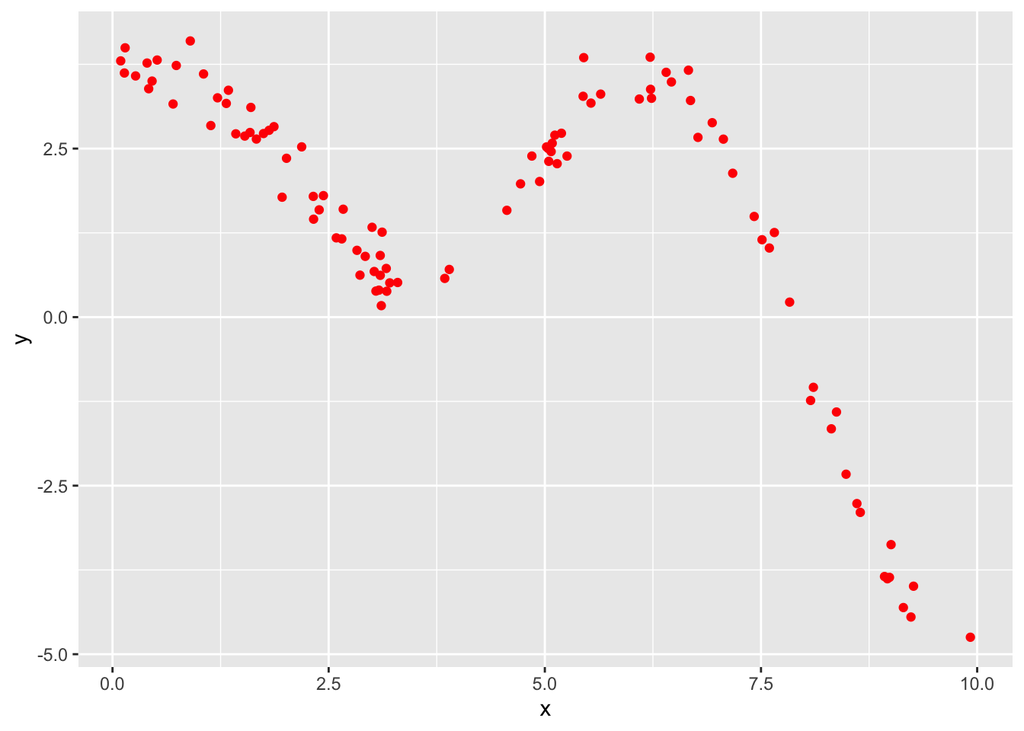

```r
# set random seed
set.seed(1234)

# import tidyverse for plotting and data wrangling
library(tidyverse)

# define function to generate data
data_func <- function(x) {
  y <- 3 + cos(x) * sqrt(x) - 0.05 * x^2
}

# generate points on the curve on the interval [0,10]
x_curve <- seq(0, 10, 0.01)
y_curve <- data_func(x_curve)
curve_df <- data.frame(x = x_curve, y = y_curve)

# simulate data
n_samples <- 100
x_sample <- runif(n_samples, 0, 10)
y_sample <- rnorm(n = n_samples, mean = data_func(x_sample), sd = 0.3)
sample_df <- data.frame(x = x_sample, y = y_sample)

# plot data
ggplot(data = sample_df, aes(x = x, y = y)) +
  geom_point(color = "red")
```

Just given the red points, if we wanted to fit a model relating $x$ and $y$, a simple linear regression would be a poor choice. See the least squares regression line in blue below – clearly it does not fit the data well, and the usual linear-regression language (“for each unit increase in $x$, the expected value of $y$ decreases by…”) is quite misleading.

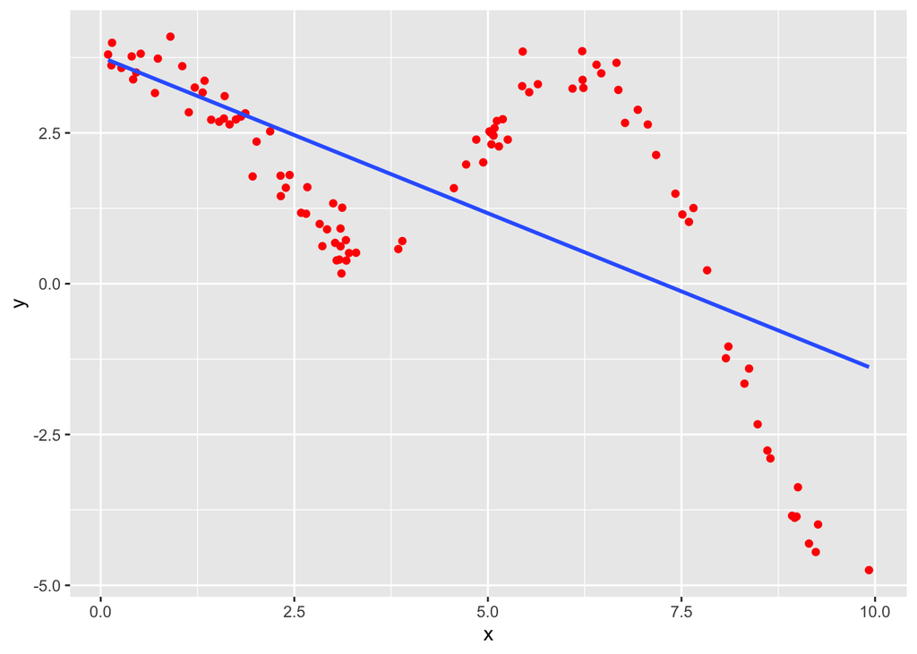

```r
# plot with regression line
ggplot(data = sample_df, aes(x = x, y = y)) +
  geom_point(color = "red") +
  geom_smooth(method = "lm", se = FALSE)
```

## So it’s not linear… what can we do?

### Idea 1: Fit a parametric nonlinear function relating x and y

Ok, if we shouldn’t fit a line, then what? One initial idea might be to explicitly specify some other functional relationship between $x$ and $y$ and fit parameters to that function. This might make sense when the relationship is reasonably simple – e.g., sometimes the data appear to show a quadratic relationship. In that case, we might just add an $x^2$ term to our simple linear regression and fit a model using the regression equation:
$$y_i = \beta_0 + \beta_1 x_i +
\beta_2 x_i^2 + \varepsilon_i$$

However, given a funky relationship like the one for our data here, it’s not likely we’d be able to just intuit a nice function relating $x$ to $y$, and misspecifying a weird nonlinear function might actually be more misleading than just fitting a line.

### Idea 2: Give up and use categorical variables

A second somewhat crude (but often used) idea is just to give up on trying to fit a continuous function at all, and instead create a categorical variable indicating that the original $x_i$ is in a particular interval. E.g., we could create variable that takes the value “low” if $x$ is in the interval [0,2], “med-low” if it’s in (2,4], “med” for (4,6], “med-high” for (6,8], and “high” for (8,10].

Let’s take a look how this would work if we create such a categorical variable and then fit a linear model with data generated above.

```r
# create a categorical variable
sample_df <- sample_df |>
  mutate(x_cat = case_when(
    x <= 2 ~ "low",
    x > 2 & x <= 4 ~ "med-low",
    x > 4 & x <= 6 ~ "med",
    x > 6 & x <= 8 ~ "med-high",
    x > 8 ~ "high"
    ),
    x_cat = as.factor(x_cat),
    x_cat = fct_relevel(x_cat, "low", "med-low", "med", "med-high", "high"))

# fit a linear model
model1 <- lm(y ~ -1 + x_cat, data = sample_df)
model1
```

```
##
## Call:
## lm(formula = y ~ -1 + x_cat, data = sample_df)
##
## Coefficients:
##      x_catlow   x_catmed-low       x_catmed  x_catmed-high      x_cathigh
##         3.227          1.044          2.590          2.540         -3.053
```

Now, instead of an intercept and a slope as when fitting a simple linear regression, we have a coefficient for each of “low”, “med-low”, “med”, “med-high”, and “high”. (Note that in the lm formula, the -1 leaves out the intercept for identifiability.) Let’s see what this categorical fit looks like when we overlay it on the data.

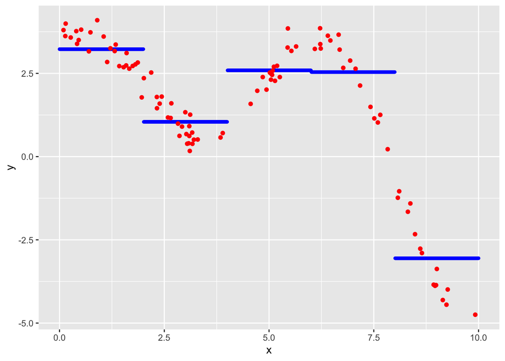

```r
# take coefficients from model
beta_cat = model1$coefficients

# create function to evaluate estimated y-values for given x-values
cat_func <- function(x) {
  est = beta_cat[1] * (x <= 2) +
    beta_cat[2] * (x > 2 & x <= 4) +
    beta_cat[3] * (x > 4 & x <= 6) +
    beta_cat[4] * (x > 6 & x <= 8) +
    beta_cat[5] * (x > 8)
  return(est)
}

# create fitted curve
curve_df$y_cat <- cat_func(curve_df$x)

# plot fitted curve over the data
ggplot(data = curve_df, aes(x = x, y = y_cat)) +
  geom_point(color = "blue", size = 1) +
  geom_point(data = sample_df, aes(x = x, y = y), color = "red") +
  labs(y = "y")
```

Looking at the plot above, this categorical approach at least seems to avoid some of the issues of fitting a line – i.e., it is able to capture the behavior that as x increases, y decreases, then increases again, and then decreases dramatically for high x-values near x = 10. But… if we wanted to use this function to predict values of y for a given x, it could give some pretty bad results. As one example, we’d make super different predictions for x = 7.99 vs. x = 8.01, both of which would be way off from where the actual y-values are observed.

### Philosophical Aside: Categorical variables as sums of basis functions

When we create a categorical variable out of a continuous one and use it for linear regression like we did above, a somewhat more abstract way to think about what we’re doing is that instead of modeling the relationship between x and y as a single linear function, as in
$$y_i = \beta_0 + \beta_1 x_i +
\varepsilon_i$$
we’re modeling the relationship as a weighted sum of five different functions, as in

$$y_i = \beta_1f_1(x_i) + \beta_2f_2(x_i)
+ \beta_3f_3(x_i) + \beta_4f_4(x_i) + \beta_5f_5(x_i) +
\varepsilon_i$$
where in this case we’ve chosen $f_1$ through $f_5$ to be the functions:
$$f_1(x) = \left\{\begin{array}{ll}
1 & : x \in [0,2]\\
0 & : otherwise
\end{array}
\right.$$
$$f_2(x) =
\left\{\begin{array}{ll}
1 & : x \in (2,4]\\
0 & : otherwise
\end{array}
\right.$$
$$f_3(x) =
\left\{\begin{array}{ll}
1 & : x \in (4,6]\\
0 & : otherwise
\end{array}
\right.$$
$$f_4(x) =
\left\{\begin{array}{ll}
1 & : x \in (6,8]\\
0 & : otherwise
\end{array}
\right.$$
$$f_5(x) =
\left\{\begin{array}{ll}
1 & : x \in (8,10]\\
0 & : otherwise
\end{array}
\right.$$

If the above doesn’t make total sense, I’d encourage you to stare at it for a minute and try to relate it back to the previous section (in particular, the graph there). Once you wrap your head around thinking of the relationship between x and y as a sum of simple functions like the ones listed above, a pretty natural question becomes – what if we chose a smarter list (or “basis”) of functions than the simple 1/0 ones that correspond to categorical variables? That is, it’d be awesome if we could find a list of functions $f_1,...,f_K$ such that

1. the functions are general enough that we can use them to model a wide range of nonlinear functions without worrying too much about fine-tuning $f_1, ..., f_K$ for each regression we do, but
2. they’re still interesting enough to express more complicated relationships than the clunky piecewise horizontal functions we get with categorical variables.

### Idea 3: Splines!!!

One answer to choosing the functions above comes in the form of “splines”. Actually, the term splines is pretty general and refers to a whole class of functions defined by piecewise polynomials – see Wikipedia for a more technical discussion and [chapter 2 of Frank Harrell’s book](https://hbiostat.org/doc/rms.pdf) for an alternate presentation of using them in regression.

If you want to totally ignore the above expression, that’s probably ok for now, since there are R packages that can deal with the implementation details for you (more on this below). But I think it’s worth at least getting a high-level idea of what’s going on. Each basis function $b_h$ is defined on an interval between $x = x_h$ and $x = x_{h+4}$, with the particular expression varying within that range, and is zero everywhere else. The variable $\delta$ refers to the distance between $x_h$ and $x_{h+1}$. So, to choose a basis of B-splines for a particular problem, we need to choose a starting point $x_0$, an ending point $x_H$, and the number of functions we want to use (or equivalently, how far apart we want the center of each function to be).

To make things more concrete, the code below plots a basis of 6 B-spline basis functions, centered at x = 0, 2, 4, 6, 8, and 10, so that they are 2 units apart (i.e, $\delta = 2$). Note that they’re only shown on the interval [0,10], so part of the two functions on each edge are cut off.

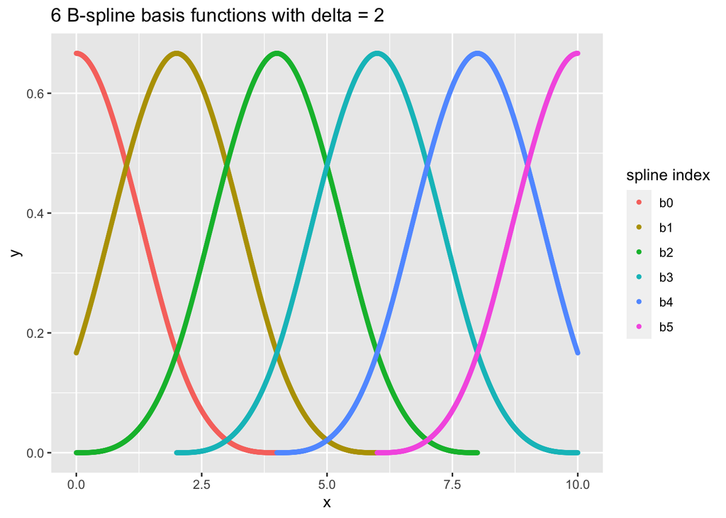

```r
# define simple b-spline function
b_func <- function(x, xh, delta) {
  u1 <- (x - xh) / delta
  u2 <- (x - (xh + delta)) / delta
  u3 <- (x - (xh + 2 * delta)) /delta
  u4 <- (x - (xh + 3 * delta)) / delta
  if (x > xh & x <= xh + delta) {
    return(u1^3 / 6)
  }
  else if (x > xh + delta & x <= xh + 2 * delta) {
    return((1 + 3*u2 + 3*u2^2 - 3*u2^3) / 6)
  }
  else if (x > xh + 2*delta & x <= xh + 3 * delta) {
    return((4 - 6*u3^2 + 3*u3^3) / 6)
  }
  else if (x > xh + 3*delta & x <= xh + 4 * delta) {
    return((1 - 3*u4 + 3*u4^2 - u4^3) / 6)
  }
  else {
    return(0)
  }
}

# populate a single spline with corresponding y-values
x_spline_demo <- seq(-4, 4, 0.01)
y_spline_demo <- rep(NA, length(x_spline_demo))
for (i in 1:length(y_spline_demo)) {
  y_spline_demo[i] <- b_func(x = x_spline_demo[i], xh = -4, delta = 2)
}

# duplicate the above with translated x-values
x_spline_demo <- c(x_spline_demo, x_spline_demo + 2, x_spline_demo + 4,
                   x_spline_demo + 6, x_spline_demo + 8, x_spline_demo + 10)
y_spline_demo <- rep(y_spline_demo, 6)
spline_index <- rep(c("b0","b1","b2","b3","b4","b5"),
                    each=length(x_spline_demo) / 6)

# create a dataframe and filter out x-values outside [0,10]
spline_demo_df <- data.frame(x = x_spline_demo, y = y_spline_demo,
                             index = spline_index) |>
  filter(x >= 0 & x <= 10)

# plot basis of splines
ggplot(data = spline_demo_df, aes(x = x, y = y, color = as.factor(index))) +
  geom_point(size = 1) +
  labs(color = "spline index",
       title = "6 B-spline basis functions with delta = 2")
```

There are a few things worth noting from the above. First, unlike the categorical setup where a given x value only belonged to a single category (corresponding to a single function $f_k$), here the basis functions overlap. In particular, for a given x-value, there might be as many as four B-spline basis functions that have nonzero values at that x. For example, at x=5, functions b1, b2, b3, and b4 are all nonzero. On one hand, this will make interpreting individual coefficients of the functions more difficult when we use them for regression, since each function isn’t solely “in charge” of a given region. But, because different functions can “compensate” some for each other, sums of the functions can be way more expressive than if they didn’t overlap.

To get a sense of what a weighted sum of the above functions might look like, below I’ve plotted the example
$$y
= 2b_0(x) - 3b_1(x) + b_2(x) + 2b_3(x) + 5b_4(x) - 4b_5(x).$$
I think it’s worth taking a moment to think about how the curve below matches up to the weights on the basis functions from above.

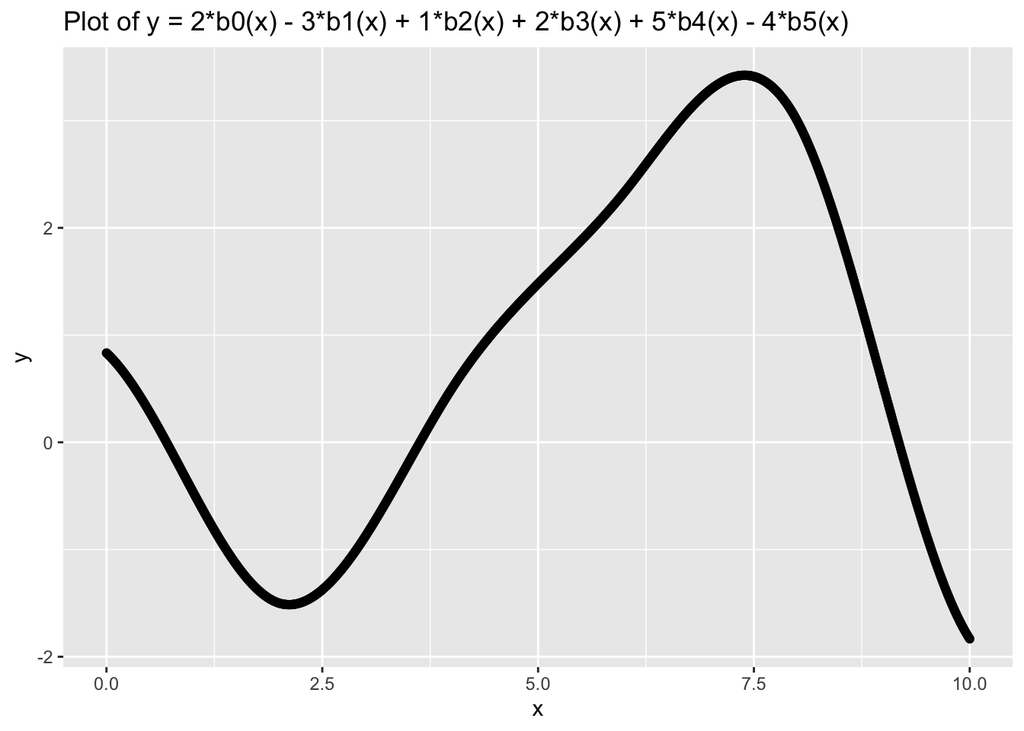

```r
# function for weighted sums of the above spline basis
spline_sum <- function(x, beta = c(1,1,1,1,1,1)) {
  y <- beta[1] * b_func(x, -4, 2) + #b0
    beta[2] * b_func(x, -2, 2) + #b1
    beta[3] * b_func(x, 0, 2) + #b2
    beta[4] * b_func(x, 2, 2) + #b3
    beta[5] * b_func(x, 4, 2) + #b4
    beta[6] * b_func(x, 6, 2) #b5
  return(y)
}

# simulate data
beta_example <- c(2, -3, 1, 2, 5, -4) # set the coefficients
x_spline <- seq(0, 10, 0.01)
y_spline <- rep(NA, length(x_spline))
for (i in 1:length(y_spline)) {
  y_spline[i] <- spline_sum(x_spline[i], beta = beta_example)
}

# make dataframe and plot simulated function
spline_example <- data.frame(x = x_spline, y = y_spline)
ggplot(data = spline_example, aes(x = x, y = y)) +
  geom_point() +
  labs(title = "Plot of y = 2*b0(x) - 3*b1(x) + 1*b2(x) + 2*b3(x) + 5*b4(x) - 4*b5(x)")
```

One thing that may surprise you about the resulting curve is that it’s really smooth all the way across – not only are there no big jumps like there were in the categorical case from earlier, there aren’t even any sharp points. This is really the magic (mathemagic, if you will…) of using these spline bases – not only are cubic B-splines continuous; their first and second derivatives are also continuous! With this in mind, the complicated-looking expression for the basis functions from earlier might start to feel a little more justified – it’s chosen carefully so that when the functions are all added up (with any associated weights), they fit together just right at their start and end points.

## Back to the data

Ok, so splines seem cool. But let’s see how the above spline basis does on the actual data I generated from earlier. To demystify everything as much as possible, I’ve implemented fitting the model from scratch below, including calculating the ordinary least squares (OLS) fit for the coefficients – the fitted coefficients for b0 through b5 are saved as “beta_fit” and printed below.

```r
# create B-spline matrix for x's generated above
X_mat <- matrix(nrow = length(x_sample), ncol = 6)

# fill each column with the appropriate spline function
for (i in 1:nrow(X_mat)) {
  X_mat[i,1] <- b_func(x_sample[i], -4, 2)
  X_mat[i,2] <- b_func(x_sample[i], -2, 2)
  X_mat[i,3] <- b_func(x_sample[i], 0, 2)
  X_mat[i,4] <- b_func(x_sample[i], 2, 2)
  X_mat[i,5] <- b_func(x_sample[i], 4, 2)
  X_mat[i,6] <- b_func(x_sample[i], 6, 2)
}

# estimate betas with OLS
beta_fit <- solve(t(X_mat) %*% X_mat) %*% t(X_mat) %*% y_sample
beta_fit
```

```
##            [,1]
## [1,]  4.7901703
## [2,]  2.4694788
## [3,] -1.2121994
## [4,]  5.9811964
## [5,] -0.3103033
## [6,] -7.7230986
```

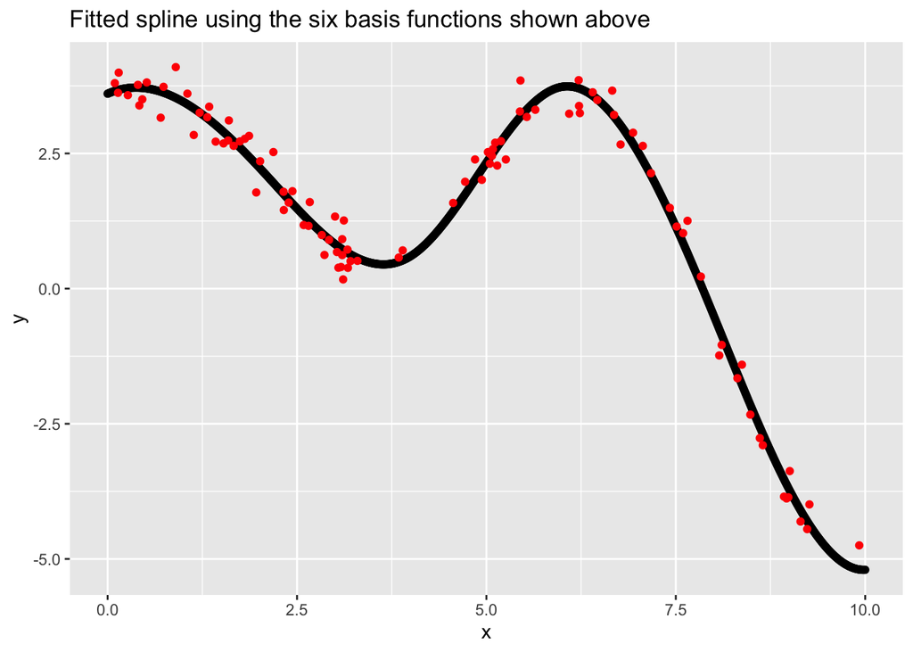

```r
# create fitted curve
spline_example$fitted_curve <- rep(NA, nrow(spline_example))
for (i in 1:nrow(spline_example)) {
  spline_example$fitted_curve[i] <- spline_sum(spline_example$x[i],
                                               beta = beta_fit)
}

# plot the results
ggplot(spline_example, aes(x = x, y = fitted_curve)) +
  geom_point() +
  geom_point(data = sample_df, aes(x = x, y = y), color = "red") +
  labs(y = "y",
       title = "Fitted spline using the six basis functions shown above")
```

Oh man, that’s pretty!! Clearly a dramatically better fit than the options I tried earlier. As one final check, I’ve also plotted the fitted spline alongside the actual function used to generate the data at the beginning of the post.

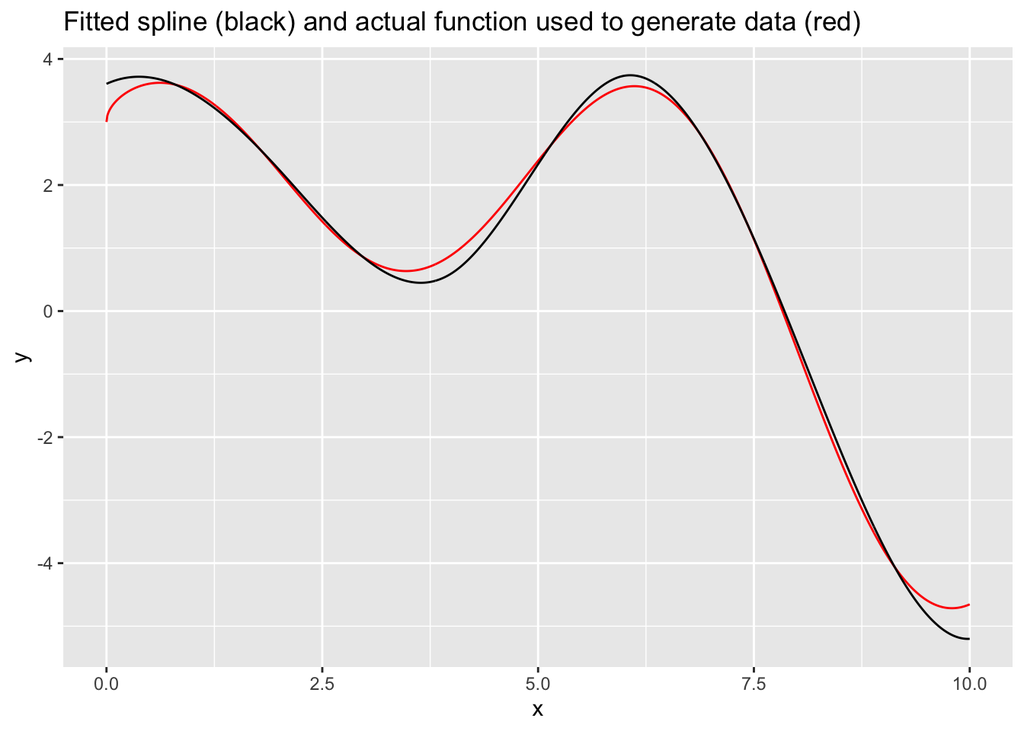

```r
# compare spline fit to actual function used to generate the data
ggplot(data = curve_df, aes(x = x, y = y)) +
  geom_line(color = "red") +
  geom_line(data = spline_example, aes(x = x, y = fitted_curve)) +
  labs(title = "Fitted spline (black) and actual function used to generate data (red)")
```

There’s a little discrepancy at a few places, but considering we just fit to 100 points with added noise, this isn’t bad at all!

## Practical concerns

### How to choose number and location of basis functions?

Hopefully the above gave you some conceptual understanding of what splines are good for and how they work. However, if you want to use them in practice there are a few decisions I’ve glossed over. The main one is that in general, you definitely shouldn’t just go around using this exact basis of 6 equally-spaced functions over the range [0,10]. Based on your context, sample size, and level of noise, you’ll want to carefully choose the number of functions and how they’re spaced out. Intuitively, if we added more and more basis functions spaced more and more closely together, we would be able to model more complicated functions, but at some point we’d risk overfitting by creating functions that are too “wiggly.”

Note that if you read more about selecting the placement of these basis functions, people generally discuss it in terms of the placement of “knots,” which for B-splines typically refers to the points at which the nonzero parts of the functions start and end. (So in our basis above, the knots would be -4, -2, 0, 2, 4, 6, 8, 10, 12 and 14, where the points above 10 and below 0 indicate the endpoints of the two rightmost and two leftmost functions, which occur outside the [0,10] interval.)

Again see Chapter 2 of [Harrell’s Regression Modeling Strategies](https://hbiostat.org/doc/rms.pdf) for a more detailed discussion about choices here. But in general, the spacing seems to be less critical than the number of functions used. To choose the optimal number, a simple strategy is to just try different values by doing cross-validation for each one, and then selecting the number that gives the best predictive performance (e.g., in terms of RMSE).

Finally, as both a teaser and a motivation for me to write more spline posts, an alternative to choosing the right number of basis functions is to just choose a really large number (potentially hundreds) of functions, but then penalize differences between adjacent coefficients when fitting the model (rather than just using OLS). At least in theory, such an approach gives the best of both worlds – lots of expressiveness but minimal overfitting. Eilers and Marx have a [recent book on “P-splines”](https://www.amazon.com/Practical-Smoothing-Paul-H-C-Eilers/dp/1108482953), which are just bases of B-splines combined with such a penalty.

### Do I really have to code everything from scratch like you did here??

Definitely not. I like doing so when I’m first wrapping my head around a topic, but there are a number of R packages that can handle the details for you. Below, I’ve used the “splines” package to implement the same regression model from above, but with a fraction of the code. Observe that other the coefficients here match the ones from beta_fit above (other than rounding a few digits earlier). And note that here, you could quite easily use the spline matrix from the package as just one part of doing a regression with other covariates (perhaps using splines for some of them as well).

```r
library(splines)
X_mat_package <- splineDesign(knots = c(-4,-2,0,2,4,6,8,10,12,14),
                              x = sample_df$x,
                              outer.ok = TRUE)

lm(sample_df$y ~ -1 + X_mat_package)
```

```
##
## Call:
## lm(formula = sample_df$y ~ -1 + X_mat_package)
##
## Coefficients:
## X_mat_package1  X_mat_package2  X_mat_package3  X_mat_package4  X_mat_package5
##         4.7902          2.4695         -1.2122          5.9812         -0.3103
## X_mat_package6
##        -7.7231
```

## Summary

I hope this has been a helpful introduction to using splines in regression modeling. As hinted above, I’m hoping to write more posts, but I’ll leave this for now as a stopping point. Thanks for reading!

## Bibliography

Eilers, Paul HC, and Brian D Marx. 2021. *Practical Smoothing: The Joys of p-Splines*. Cambridge University Press.

Gelman, Andrew, John B Carlin, Hal S Stern, David B Dunson, Aki Vehtari, and Donald B Rubin. 2013. *Bayesian Data Analysis*. CRC Press.

Harrell, Frank E. 2017. “Regression Modeling Strategies.” *Bios* 330 (2018): 14.

Wikipedia. 2023. “Spline (mathematics) — Wikipedia, the Free Encyclopedia.” http://en.wikipedia.org/w/index.php?title=Spline%20(mathematics)&oldid=1124401166.